# Project: Investigate a Dataset (patient noshow appointment)

- Introduction
- Data Wrangling
- Exploratory Data Analysis
- Conclusions

## Introduction

This dataset collects information from 100k medical appointments in Brazil and is focused on the question of whether or not patients show up for their appointment. A number of characteristics about the patient are included in each row.

**‘ScheduledDay’** tells us on what day the patient set up their appointment.  
**‘Neighborhood’** indicates the location of the hospital.  
**‘Scholarship’** indicates whether or not the patient is enrolled in Brasilian welfare program Bolsa Família.

```python
#import statements for all of the packages

import numpy as np
import pandas as pd
import matplotlib.pyplot as plt
import seaborn as sns
%matplotlib inline
```

## Data Wrangling

In this section we load our dataset from CSV file and check for dataset cleanliness and then clean the dataset for analysis

### General Properties

```python
# Load your data and print out a few lines. Perform operations to inspect data if there is null values or duplicates

df = pd.read_csv('noshowappointments-kagglev2-may-2016.csv')
df.head()
```

|  | PatientId | AppointmentID | Gender | ScheduledDay | AppointmentDay | Age | Neighbourhood | Scholarship | Hipertension | Diabetes | Alcoholism | Handcap | SMS_received | No-show |
| --- | --- | --- | --- | --- | --- | --- | --- | --- | --- | --- | --- | --- | --- | --- |
| 0 | 2.987250e+13 | 5642903 | F | 2016-04-29T18:38:08Z | 2016-04-29T00:00:00Z | 62 | JARDIM DA PENHA | 0 | 1 | 0 | 0 | 0 | 0 | No |
| 1 | 5.589978e+14 | 5642503 | M | 2016-04-29T16:08:27Z | 2016-04-29T00:00:00Z | 56 | JARDIM DA PENHA | 0 | 0 | 0 | 0 | 0 | 0 | No |
| 2 | 4.262962e+12 | 5642549 | F | 2016-04-29T16:19:04Z | 2016-04-29T00:00:00Z | 62 | MATA DA PRAIA | 0 | 0 | 0 | 0 | 0 | 0 | No |
| 3 | 8.679512e+11 | 5642828 | F | 2016-04-29T17:29:31Z | 2016-04-29T00:00:00Z | 8 | PONTAL DE CAMBURI | 0 | 0 | 0 | 0 | 0 | 0 | No |
| 4 | 8.841186e+12 | 5642494 | F | 2016-04-29T16:07:23Z | 2016-04-29T00:00:00Z | 56 | JARDIM DA PENHA | 0 | 1 | 1 | 0 | 0 | 0 | No |

```python
#exploring dataset shape(no of columns and rows)
df.shape
```

```
(110527, 14)
```

```python
#exploring dataset datatypes and more info about each column and missing values
df.info()
```

```
<class 'pandas.core.frame.DataFrame'>
RangeIndex: 110527 entries, 0 to 110526
Data columns (total 14 columns):
 #   Column          Non-Null Count   Dtype
---  ------          --------------   -----
 0   PatientId       110527 non-null  float64
 1   AppointmentID   110527 non-null  int64
 2   Gender          110527 non-null  object
 3   ScheduledDay    110527 non-null  object
 4   AppointmentDay  110527 non-null  object
 5   Age             110527 non-null  int64
 6   Neighbourhood   110527 non-null  object
 7   Scholarship     110527 non-null  int64
 8   Hipertension    110527 non-null  int64
 9   Diabetes        110527 non-null  int64
 10  Alcoholism      110527 non-null  int64
 11  Handcap         110527 non-null  int64
 12  SMS_received    110527 non-null  int64
 13  No-show         110527 non-null  object
dtypes: float64(1), int64(8), object(5)
memory usage: 9.7+ MB
```

```python
#statistic summary for data to explore any odd values
df.describe()
```

|  | PatientId | AppointmentID | Age | Scholarship | Hipertension | Diabetes | Alcoholism | Handcap | SMS_received |
| --- | --- | --- | --- | --- | --- | --- | --- | --- | --- |
| count | 1.105270e+05 | 1.105270e+05 | 110527.000000 | 110527.000000 | 110527.000000 | 110527.000000 | 110527.000000 | 110527.000000 | 110527.000000 |
| mean | 1.474963e+14 | 5.675305e+06 | 37.088874 | 0.098266 | 0.197246 | 0.071865 | 0.030400 | 0.022248 | 0.321026 |
| std | 2.560949e+14 | 7.129575e+04 | 23.110205 | 0.297675 | 0.397921 | 0.258265 | 0.171686 | 0.161543 | 0.466873 |
| min | 3.921784e+04 | 5.030230e+06 | -1.000000 | 0.000000 | 0.000000 | 0.000000 | 0.000000 | 0.000000 | 0.000000 |
| 25% | 4.172614e+12 | 5.640286e+06 | 18.000000 | 0.000000 | 0.000000 | 0.000000 | 0.000000 | 0.000000 | 0.000000 |
| 50% | 3.173184e+13 | 5.680573e+06 | 37.000000 | 0.000000 | 0.000000 | 0.000000 | 0.000000 | 0.000000 | 0.000000 |
| 75% | 9.439172e+13 | 5.725524e+06 | 55.000000 | 0.000000 | 0.000000 | 0.000000 | 0.000000 | 0.000000 | 1.000000 |
| max | 9.999816e+14 | 5.790484e+06 | 115.000000 | 1.000000 | 1.000000 | 1.000000 | 1.000000 | 4.000000 | 1.000000 |

in describe function there is some confusing values need to check like in age column value of -1 and 115 & in Handcap column value of 4 in max value & in sms_received column that 25% of patient doesnot receive message

```python
#find which row containing the -1 value in age column
age_nve=df.query('Age == -1')
age_nve
```

|  | PatientId | AppointmentID | Gender | ScheduledDay | AppointmentDay | Age | Neighbourhood | Scholarship | Hipertension | Diabetes | Alcoholism | Handcap | SMS_received | No-show |
| --- | --- | --- | --- | --- | --- | --- | --- | --- | --- | --- | --- | --- | --- | --- |
| 99832 | 4.659432e+14 | 5775010 | F | 2016-06-06T08:58:13Z | 2016-06-06T00:00:00Z | -1 | ROMÃO | 0 | 0 | 0 | 0 | 0 | 0 | No |

we will drop this row in cleaning phase

```python
#find how many rows containing 115 value in age column
age_high = df.query('Age == 115')
age_high
```

|  | PatientId | AppointmentID | Gender | ScheduledDay | AppointmentDay | Age | Neighbourhood | Scholarship | Hipertension | Diabetes | Alcoholism | Handcap | SMS_received | No-show |
| --- | --- | --- | --- | --- | --- | --- | --- | --- | --- | --- | --- | --- | --- | --- |
| 63912 | 3.196321e+13 | 5700278 | F | 2016-05-16T09:17:44Z | 2016-05-19T00:00:00Z | 115 | ANDORINHAS | 0 | 0 | 0 | 0 | 1 | 0 | Yes |
| 63915 | 3.196321e+13 | 5700279 | F | 2016-05-16T09:17:44Z | 2016-05-19T00:00:00Z | 115 | ANDORINHAS | 0 | 0 | 0 | 0 | 1 | 0 | Yes |
| 68127 | 3.196321e+13 | 5562812 | F | 2016-04-08T14:29:17Z | 2016-05-16T00:00:00Z | 115 | ANDORINHAS | 0 | 0 | 0 | 0 | 1 | 0 | Yes |
| 76284 | 3.196321e+13 | 5744037 | F | 2016-05-30T09:44:51Z | 2016-05-30T00:00:00Z | 115 | ANDORINHAS | 0 | 0 | 0 | 0 | 1 | 0 | No |
| 97666 | 7.482346e+14 | 5717451 | F | 2016-05-19T07:57:56Z | 2016-06-03T00:00:00Z | 115 | SÃO JOSÉ | 0 | 1 | 0 | 0 | 0 | 1 | No |

for 115 years old people they are all females and 4 of them are handcap and only to attended the appointment here data is resonable so there is no error in data entry about these row and we donot need to remove

```python
#check for values of hadcap column which only must be 0 or 1
hcp_odd = df.Handcap.value_counts()
hcp_odd
```

```
0    108286
1      2042
2       183
3        13
4         3
Name: Handcap, dtype: int64
```

there is 199 rows from all dataset has an entry error so we will delete these rows in the cleaning phase

```python
#check for unique values in our key column (patient id)
df['PatientId'].nunique()
```

```
62299
```

there is only 62299 unique patient Id out of 110527, so we need to check for duplication

```python
#check for duplicates
df.duplicated().sum()# there is no duplicates in data set
```

```
0
```

it shows that there is no identical duplicates in dataset so lets check for dupplicates in our key column(patientid)

```python
#check for dupplicates in patient Id column
df['PatientId'].duplicated().sum()
```

```
48228
```

there is 48228 out of 110527 duplicated patient ID, so lets check if these dupplicated rows have the same status of show and in the same day of appointment

```python
df.duplicated(['PatientId','No-show','AppointmentDay']).sum()
```

```
7378
```

there is 7378 duplicated patient ID in the same appointment day with the same status of show so we need to remove duplicates in cleaning phase

```python
#check for null values
df.isnull().sum()#there is no null values
```

```
PatientId         0
AppointmentID     0
Gender            0
ScheduledDay      0
AppointmentDay    0
Age               0
Neighbourhood     0
Scholarship       0
Hipertension      0
Diabetes          0
Alcoholism        0
Handcap           0
SMS_received      0
No-show           0
dtype: int64
```

### Data Cleaning

in this section we clean our data from explored un necessary data

```python
#cleaning phase remove the row with -1 in Age column
df.drop([99832], inplace=True)
```

```python
#removing hancap row entries of 2,3,4
df.drop(df[df['Handcap'] > 1].index, inplace=True)
```

```python
#checking for values of handcap column after drop
df.Handcap.value_counts()
```

```
0    108285
1      2042
Name: Handcap, dtype: int64
```

```python
#removing the dupplicated patient id with the same show status in the same day of attendance
df.drop_duplicates(['PatientId','No-show','AppointmentDay'], inplace= True)
```

```python
#check for duplicates again in Patient id
df['PatientId'].duplicated().sum()
```

```
40776
```

there is still dupplicated values lets check if duplicates with the same show status

```python
df.duplicated(['PatientId','No-show']).sum()
```

```
31277
```

so we nead to clean only duplicated patient id with the same show status

```python
df.drop_duplicates(['PatientId','No-show'], inplace=True)
```

```python
#check again for duplicates in patient ID
df['PatientId'].duplicated().sum()
```

```
9499
```

Now we don't need for these columns(AppointmentID,AppointmentDay,ScheduledDay), so i will drop these columns

```python
#drop unnecessary columns
df.drop(['AppointmentID','AppointmentDay','ScheduledDay'], axis = 1, inplace=True)
df.head()
```

|  | PatientId | Gender | Age | Neighbourhood | Scholarship | Hipertension | Diabetes | Alcoholism | Handcap | SMS_received | No-show |
| --- | --- | --- | --- | --- | --- | --- | --- | --- | --- | --- | --- |
| 0 | 2.987250e+13 | F | 62 | JARDIM DA PENHA | 0 | 1 | 0 | 0 | 0 | 0 | No |
| 1 | 5.589978e+14 | M | 56 | JARDIM DA PENHA | 0 | 0 | 0 | 0 | 0 | 0 | No |
| 2 | 4.262962e+12 | F | 62 | MATA DA PRAIA | 0 | 0 | 0 | 0 | 0 | 0 | No |
| 3 | 8.679512e+11 | F | 8 | PONTAL DE CAMBURI | 0 | 0 | 0 | 0 | 0 | 0 | No |
| 4 | 8.841186e+12 | F | 56 | JARDIM DA PENHA | 0 | 1 | 1 | 0 | 0 | 0 | No |

Now lets take alook on the columns labels for any necessary changes (typo , _, etc)

```python
#renaming hipertension to Hypertension
df.rename(columns={'Hipertension':'Hypertension'}, inplace=True)
#renaming No-show to No_show
df.rename(columns={'No-show':'No_show'}, inplace=True)
#renaming Handcap to Handicap
df.rename(columns={'Handcap':'Handicap'}, inplace=True)
df.head()
```

|  | PatientId | Gender | Age | Neighbourhood | Scholarship | Hypertension | Diabetes | Alcoholism | Handicap | SMS_received | No_show |
| --- | --- | --- | --- | --- | --- | --- | --- | --- | --- | --- | --- |
| 0 | 2.987250e+13 | F | 62 | JARDIM DA PENHA | 0 | 1 | 0 | 0 | 0 | 0 | No |
| 1 | 5.589978e+14 | M | 56 | JARDIM DA PENHA | 0 | 0 | 0 | 0 | 0 | 0 | No |
| 2 | 4.262962e+12 | F | 62 | MATA DA PRAIA | 0 | 0 | 0 | 0 | 0 | 0 | No |
| 3 | 8.679512e+11 | F | 8 | PONTAL DE CAMBURI | 0 | 0 | 0 | 0 | 0 | 0 | No |
| 4 | 8.841186e+12 | F | 56 | JARDIM DA PENHA | 0 | 1 | 1 | 0 | 0 | 0 | No |

```python
df.shape
```

```
(71689, 11)
```

```python
#drop also unnecessary patientid column
df.drop(['PatientId'], axis = 1 , inplace=True)
df.head()
```

|  | Gender | Age | Neighbourhood | Scholarship | Hypertension | Diabetes | Alcoholism | Handicap | SMS_received | No_show |
| --- | --- | --- | --- | --- | --- | --- | --- | --- | --- | --- |
| 0 | F | 62 | JARDIM DA PENHA | 0 | 1 | 0 | 0 | 0 | 0 | No |
| 1 | M | 56 | JARDIM DA PENHA | 0 | 0 | 0 | 0 | 0 | 0 | No |
| 2 | F | 62 | MATA DA PRAIA | 0 | 0 | 0 | 0 | 0 | 0 | No |
| 3 | F | 8 | PONTAL DE CAMBURI | 0 | 0 | 0 | 0 | 0 | 0 | No |
| 4 | F | 56 | JARDIM DA PENHA | 0 | 1 | 1 | 0 | 0 | 0 | No |

## Exploratory Data Analysis

Now that W've trimmed and cleaned our data, We're ready to move on to exploration. Computing statistics and creating visualizations with the goal of addressing the research questions.

### Investigating influencing factors on the attendance rate

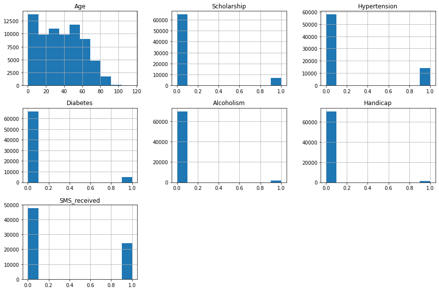

```python
#drawing histograme for each parameter in our dataframe
df.hist(figsize=(15,10));
```

```python
#dividing No show status to attend and absent
attend = df['No_show']== 'No'
```

```python
absent = df['No_show']=='Yes'
```

```python
df[attend].count(),df[absent].count()
```

```
(Gender           54057
 Age              54057
 Neighbourhood    54057
 Scholarship      54057
 Hypertension     54057
 Diabetes         54057
 Alcoholism       54057
 Handicap         54057
 SMS_received     54057
 No_show          54057
 dtype: int64,
 Gender           17632
 Age              17632
 Neighbourhood    17632
 Scholarship      17632
 Hypertension     17632
 Diabetes         17632
 Alcoholism       17632
 Handicap         17632
 SMS_received     17632
 No_show          17632
 dtype: int64)
```

```python
df[attend].mean(),df[absent].mean()
```

```
(Age             37.219435
 Scholarship      0.091274
 Hypertension     0.202712
 Diabetes         0.072720
 Alcoholism       0.023605
 Handicap         0.017223
 SMS_received     0.297242
 dtype: float64,
 Age             34.350613
 Scholarship      0.108553
 Hypertension     0.170372
 Diabetes         0.064939
 Alcoholism       0.029378
 Handicap         0.014009
 SMS_received     0.453494
 dtype: float64)
```

the average age for the attended patients is 37 years old and the average age of absent patients is 34 years old, non receiving SMS and absent are more then who recieved SMS and attended their appointment so we need to adjust SMS targeting strategy

### Question 1( Is gender of patients influence their attendance)

```python
#using groupby to get no of attendees and absents for both gender M &F to find if there any relation
df.groupby(['No_show'])['Gender'].value_counts()
```

```
No_show  Gender
No       F         34914
         M         19143
Yes      F         11489
         M          6143
Name: Gender, dtype: int64
```

|  | Gender |
| --- | --- |
| F | 34914 |
| M | 19143 |

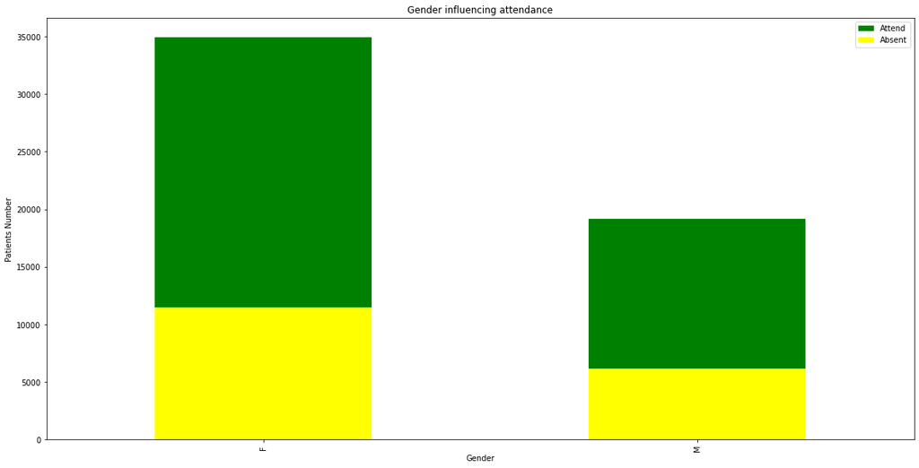

```python
def attendance(df,column,show,no_show):
    plt.figure(figsize=[20,10]);
    df[column][show].value_counts().plot(kind='bar',color='green',label='Attend');
    df[column][no_show].value_counts().plot(kind='bar',color='yellow',label='Absent');
    plt.legend();
    plt.title(column +' influencing attendance');
    plt.xlabel(column);
    plt.ylabel('Patients Number');
attendance(df,'Gender',attend,absent)
pd.DataFrame(df['Gender'][attend].value_counts())
```

there is no clear relation between the show status and the gender

### Question 2(is patient age influence the show status

| No_show | Age | Age |
| --- | --- | --- |
| No | 0 | 1828 |
|  | 1 | 1245 |
|  | 2 | 967 |
|  | 3 | 838 |
|  | 57 | 810 |
| ... | ... | ... |
| Yes | 95 | 4 |
|  | 97 | 2 |
|  | 96 | 1 |
|  | 98 | 1 |
|  | 115 | 1 |

203 rows × 1 columns

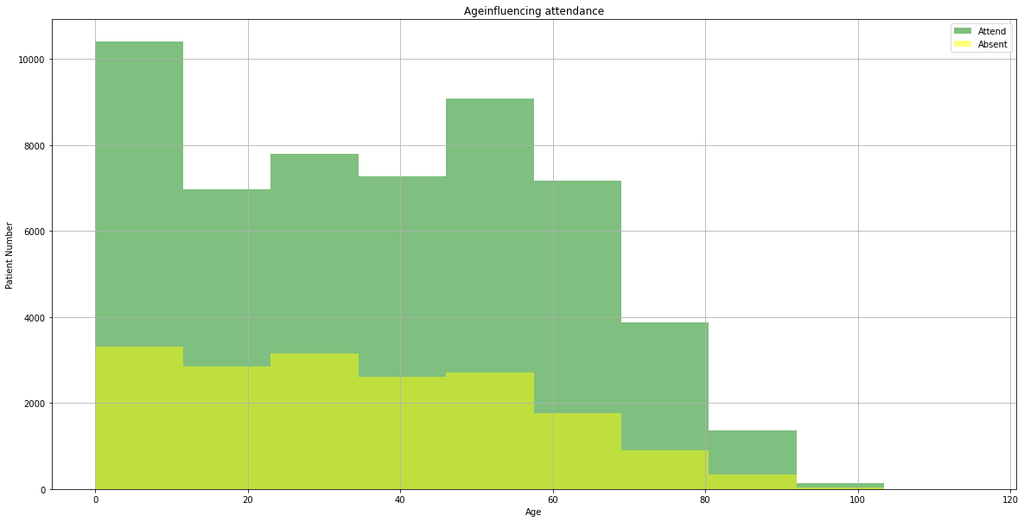

```python
#grouping age for show status to get if there relation between the age and show status

def attendance_hist(df,column,show,no_show):
    plt.figure(figsize=[20,10]);
    df[column][show].hist(alpha=.5,bins=10,color='green',label='Attend');
    df[column][no_show].hist(alpha=.5,bins=10,color='yellow',label='Absent');
    plt.legend();
    plt.title(column + 'influencing attendance');
    plt.xlabel(column);
    plt.ylabel('Patient Number');
attendance_hist(df,'Age',attend,absent)
pd.DataFrame(df.groupby(['No_show'])['Age'].value_counts())
```

It seems that there is relation between age of patients and attendance as the most attendees age range from 0(infants) to 10 while the least attendees are patients from 80 to over 100 years old

The second raise in attendence is for patients from 45 to 57 years old

### question 3(Which neibourhood has the min/max number of attendees?)

| No_show | Neighbourhood | Neighbourhood |
| --- | --- | --- |
| No | JARDIM CAMBURI | 3666 |
|  | MARIA ORTIZ | 2845 |
|  | JARDIM DA PENHA | 2155 |
|  | RESISTÊNCIA | 2094 |
|  | ITARARÉ | 1742 |
| ... | ... | ... |
| Yes | PONTAL DE CAMBURI | 12 |
|  | ILHA DO BOI | 3 |
|  | ILHA DO FRADE | 2 |
|  | ILHAS OCEÂNICAS DE TRINDADE | 2 |
|  | AEROPORTO | 1 |

160 rows × 1 columns

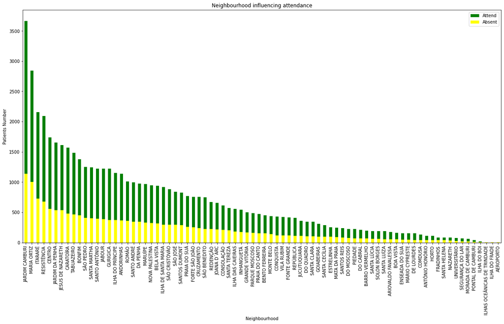

```python
attendance(df,'Neighbourhood',attend,absent);
pd.DataFrame(df.groupby(['No_show'])['Neighbourhood'].value_counts())
```

### Question 4 (does scholarship affects attendance?)

| No_show | Scholarship | Scholarship |
| --- | --- | --- |
| No | 0 | 49123 |
|  | 1 | 4934 |
| Yes | 0 | 15718 |
|  | 1 | 1914 |

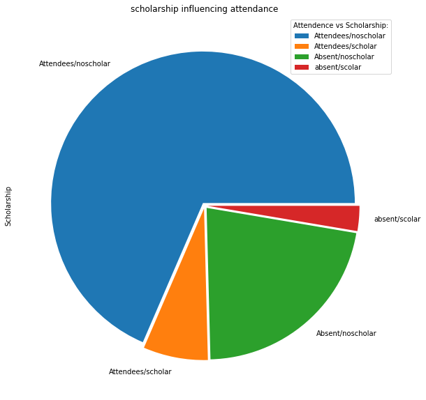

```python
plt.figure(figsize=[20,10]);
df.groupby(['No_show'])['Scholarship'].value_counts().plot(kind='pie',labels=['Attendees/noscholar','Attendees/scholar','Absent/noscholar','absent/scolar'],explode=[0.02,0.02,0.02,0.02])
plt.legend(title='Attendence vs Scholarship:');
plt.title('scholarship influencing attendance')
pd.DataFrame(df.groupby(['No_show'])['Scholarship'].value_counts())
```

it seems that majority of attendees doesn't have a scholarship, so scholarship does not has clear effect on the attendance

### Question 5(does patient with chronic disease their attendance will be affected?)

| Hypertension | Diabetes | No_show | No_show |
| --- | --- | --- | --- |
| 0 | 0 | No | 42370 |
|  |  | Yes | 14389 |
|  | 1 | No | 729 |
|  |  | Yes | 239 |
| 1 | 0 | No | 7756 |
|  |  | Yes | 2098 |
|  | 1 | No | 3202 |
|  |  | Yes | 906 |

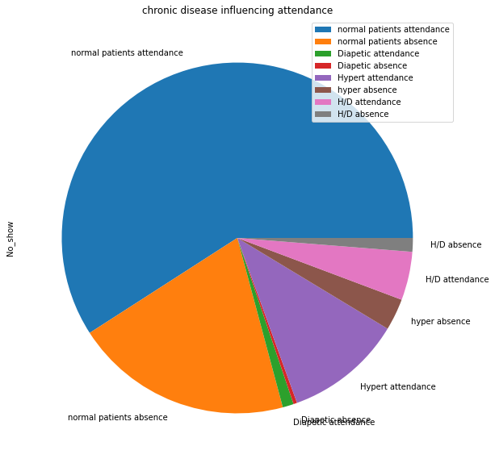

```python
plt.figure(figsize=[20,10]);
df.groupby(['Hypertension','Diabetes'])['No_show'].value_counts().plot(kind="pie",labels=['normal patients attendance','normal patients absence','Diapetic attendance','Diapetic absence','Hypert attendance','hyper absence','H/D attendance','H/D absence']);
plt.legend();
plt.title('chronic disease influencing attendance')
pd.DataFrame(df.groupby(['Hypertension','Diabetes'])['No_show'].value_counts())
```

normal patient attendace is the most percentile,although when comparing patient with cronic disease who attend vs who absent we will find that attendees with chronic disease is more than absent patient with chronic diseases aprox. 3 times so chronic disease doesnot affect attendance

### Question6(does alcoholism affect attendance?)

| No_show | Alcoholism | Alcoholism |
| --- | --- | --- |
| False | 0 | 17114 |
|  | 1 | 518 |
| True | 0 | 52781 |
|  | 1 | 1276 |

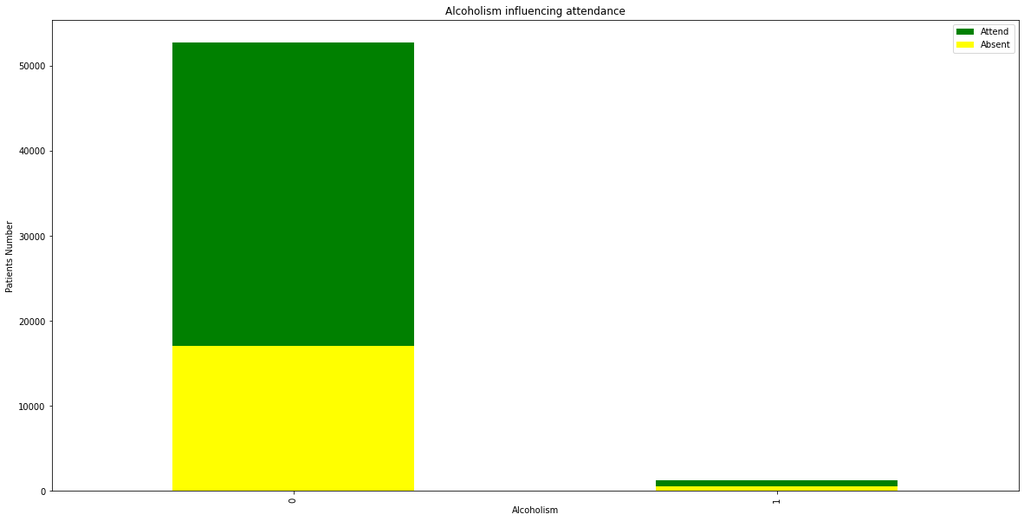

```python
attendance(df,'Alcoholism',attend,absent)
pd.DataFrame(df.groupby([attend])['Alcoholism'].value_counts())
```

in two cases of alcoholism with 1 or 0 the attendants is more than absent patient , so alcoholism is not affect attendance

### Question 6(does Handicap patients their attendance is affected)

| No_show | Handicap | Handicap |
| --- | --- | --- |
| False | 0 | 17385 |
|  | 1 | 247 |
| True | 0 | 53126 |
|  | 1 | 931 |

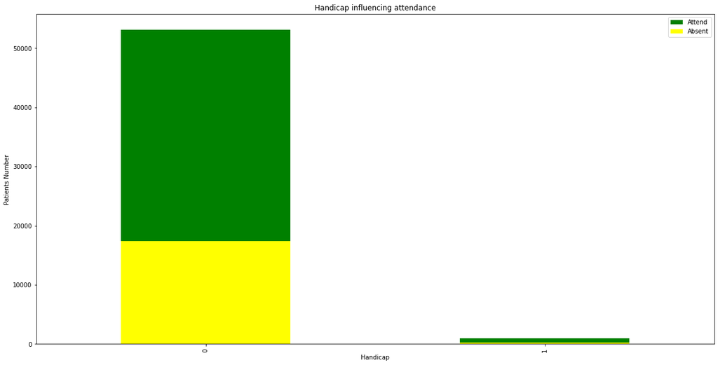

```python
attendance(df,'Handicap',attend,absent)
pd.DataFrame(df.groupby([attend])['Handicap'].value_counts())
```

in two cases of Handicap with 1 or 0 the attendants is more than absent patient , so Handicap is not affect attendance

### Question 7(Does receiving SMS affect attendance?)

| No_show | SMS_received | SMS_received |
| --- | --- | --- |
| False | 0 | 9636 |
|  | 1 | 7996 |
| True | 0 | 37989 |
|  | 1 | 16068 |

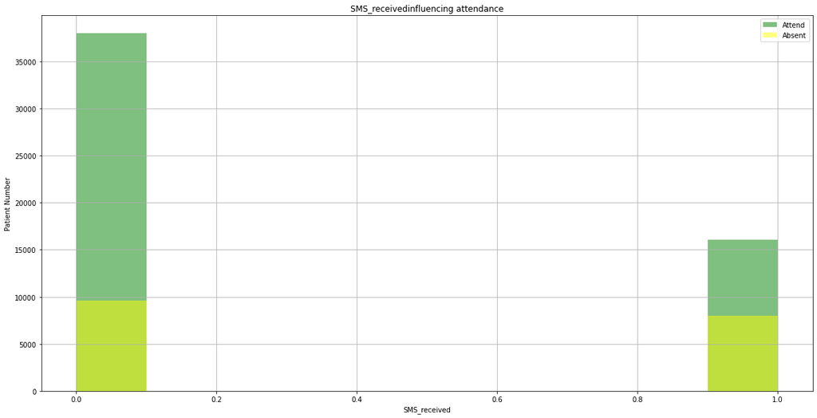

```python
attendance_hist(df,'SMS_received',attend,absent);
pd.DataFrame(df.groupby([attend])['SMS_received'].value_counts())
```

it seems that patients who did not received SMS attended their appointments more than patients received the SMS which mean we need to review our SMS targeting strategy

### compining two factors to affect attendance

| Hypertension | Diabetes | Age |
| --- | --- | --- |
| 0 | 0 | 30.717324 |
|  | 1 | 53.727023 |
| 1 | 0 | 60.239170 |
|  | 1 | 63.740162 |

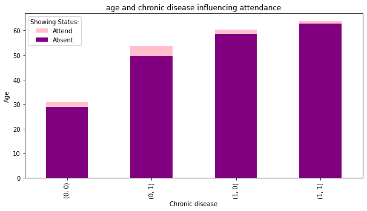

```python
#does age and chronic disease affect attendance?
plt.figure(figsize=[10,5]);
df[attend].groupby(['Hypertension','Diabetes']).mean()['Age'].plot(kind='bar',color='pink',label='Attend');
df[absent].groupby(['Hypertension','Diabetes']).mean()['Age'].plot(kind='bar',color='purple',label='Absent');
plt.legend(title='Showing Status:');
plt.title('age and chronic disease influencing attendance')
plt.xlabel('Chronic disease');
plt.ylabel('Age');
pd.DataFrame(df[attend].groupby(['Hypertension','Diabetes']).mean()['Age'])
```

There is positive correlation between age and chronic diseases but the chronic diseases doesnot affect attendance

| Gender | Age |
| --- | --- |
| F | 39.125337 |
| M | 33.743353 |

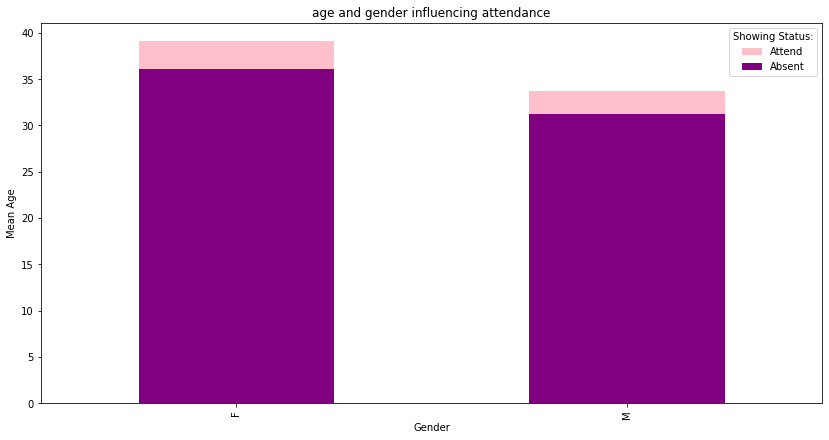

```python
#does age and gender affect attendance?
plt.figure(figsize=[14,7]);
df[attend].groupby('Gender').mean()['Age'].plot(kind='bar',color='pink',label='Attend');
df[absent].groupby('Gender').mean()['Age'].plot(kind='bar',color='purple',label='Absent');
plt.legend(title='Showing Status:');
plt.title('age and gender influencing attendance')
plt.xlabel('Gender');
plt.ylabel('Mean Age');
pd.DataFrame(df[attend].groupby('Gender').mean()['Age'])
```

| Neighbourhood | SMS_received |
| --- | --- |
| AEROPORTO | 0.166667 |
| ANDORINHAS | 0.228370 |
| ANTÔNIO HONÓRIO | 0.341935 |
| ARIOVALDO FAVALESSA | 0.203947 |
| BARRO VERMELHO | 0.338624 |
| ... | ... |
| SÃO JOSÉ | 0.333333 |
| SÃO PEDRO | 0.265165 |
| TABUAZEIRO | 0.282517 |
| UNIVERSITÁRIO | 0.280488 |
| VILA RUBIM | 0.329810 |

80 rows × 1 columns

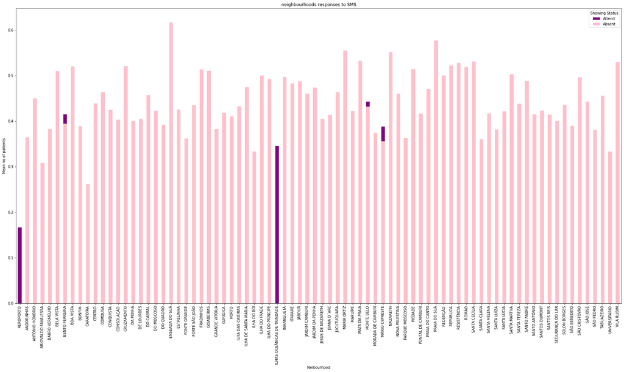

```python
#is neighbourhoods have different responses to SMS and receiving varuabilty
plt.figure(figsize=[30,15]);
df[attend].groupby('Neighbourhood').mean()['SMS_received'].plot(kind='bar',color='purple',label='Attend');
df[absent].groupby('Neighbourhood').mean()['SMS_received'].plot(kind='bar',color='pink',label='Absent');
plt.legend(title='Showing Status');
plt.title('neighbourhoods responses to SMS')
plt.xlabel('Neibourhood');
plt.ylabel('Mean no of patients');
pd.DataFrame(df[attend].groupby('Neighbourhood').mean()['SMS_received'])
```

| Neighbourhood | Age |
| --- | --- |
| AEROPORTO | 55.000000 |
| ANDORINHAS | 36.156942 |
| ANTÔNIO HONÓRIO | 40.967742 |
| ARIOVALDO FAVALESSA | 34.684211 |
| BARRO VERMELHO | 44.026455 |
| ... | ... |
| SÃO JOSÉ | 34.441176 |
| SÃO PEDRO | 35.746101 |
| TABUAZEIRO | 35.488808 |
| UNIVERSITÁRIO | 42.817073 |
| VILA RUBIM | 45.543340 |

80 rows × 1 columns

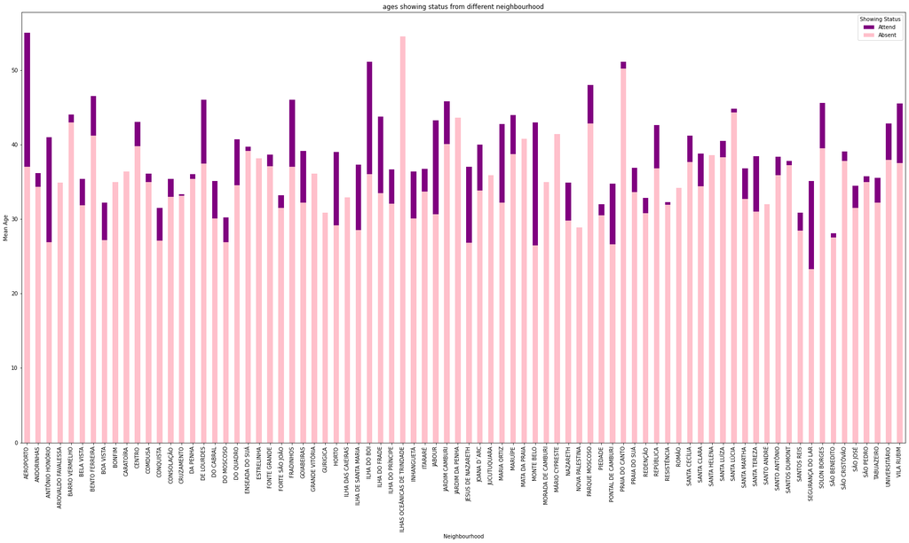

```python
#comparing ages showing status from different neighbourhood
plt.figure(figsize=[30,15]);
df[attend].groupby('Neighbourhood').mean()['Age'].plot(kind='bar',color='purple',label='Attend');
df[absent].groupby('Neighbourhood').mean()['Age'].plot(kind='bar',color='pink',label='Absent');
plt.legend(title='Showing Status');
plt.title('ages showing status from different neighbourhood')
plt.xlabel('Neighbourhood');
plt.ylabel('Mean Age');
pd.DataFrame(df[attend].groupby('Neighbourhood').mean()['Age'])
```

attended average Ages differ from neighbourhood to others ,most neighbourhood with high age average attendance is AEROPORTO

# conclusions

# Limitations:

- there is no clear relation between the show status and the gender
- Alcoholism is not affect attendance
- Handicap is not affect attendance
- Normal patient attendace is the most percentile,although when comparing patient with cronic disease who attend vs who absent we will find that attendees with chronic disease is more than absent patient with chronic diseases aprox. 3 times so chronic disease doesnot affect attendance
- Majority of attendees doesn't have a scholarship, so scholarship does not has clear effect on the attendance
- No correlation between age and gender affecting the attendance